# Identifying The Correct Bicep Curl Through Machine Learning

Robert Jeong

October 7, 2017

## Overview

One thing that people regularly do is quantify how much of a particular activity they do, but they rarely quantify how well they do it. Using the many devices in the market today, it is now possible to collect a large amount of data about personal activity. The participants were asked to perform barbell lifts correctly and incorrectly in 5 different ways. The goal is to predict the manner in which they did the exercise.

Six young health participants were asked to perform one set of 10 repetitions of the Unilateral Dumbbell Biceps Curl of 1.25kg in five different fashions: exactly according to the specification (Class A), throwing the elbows to the front (Class B), lifting the dumbbell only halfway (Class C), lowering the dumbbell only halfway (Class D) and throwing the hips to the front (Class E).

Class A corresponds to the specified execution of the exercise, while the other 4 classes correspond to common mistakes. [^1]

## Executive Summary

In this report, the study is to identify in which how the the various accelerometer meters can be used to predict when the participant performed a unilateral dumbbel bicep curl correctly. The final modeled algorthim chosen was a random forest algorithm producing a 99.2% accuracy of predicability.

## Data Exploration

The data for this project comes from the following source: [Weight Lifting Exercise Dataset](http://web.archive.org/web/20161224072740/http:/groupware.les.inf.puc-rio.br/har#weight_lifting_exercises) (Velloso, Bulling, Gellersen, Ugulino, Fuks; 2013)

A training and testing data sets was reproduced from above source and gathered for use in this report.

| DataSet | File Location | Observations | Variables |
| --- | --- | --- | --- |
| Training | https://d396qusza40orc.cloudfront.net/predmachlearn/pml-training.csv | 19622 | 160 |
| Testing | https://d396qusza40orc.cloudfront.net/predmachlearn/pml-testing.csv | 20 | 160 |

```r
# Download the training and testing data if they do not exist in working directory
trainFile <- "https://d396qusza40orc.cloudfront.net/predmachlearn/pml-training.csv"
testFile <- "https://d396qusza40orc.cloudfront.net/predmachlearn/pml-testing.csv"

if (length(list.files(path = ".", pattern = "train", ignore.case = TRUE)) == 0)
  {
    download.file(url = trainFile, destfile = "./pml-training.csv", method = "auto")
  }

if (length(list.files(path = ".", pattern = "test", ignore.case = TRUE)) == 0)
  {
    download.file(url = testFile, destfile = "./pml-testing.csv", method = "auto")
  }

# Load the training dataset and provide number of observations and variables
dTrain <- read.csv("./pml-training.csv"); dim(dTrain)
```

```
## [1] 19622   160
```

```r
# Load the testing dataset and provide number of observations and variables
dTest <- read.csv("./pml-testing.csv"); dim(dTest)
```

```
## [1]  20 160
```

In reviewing the two data sets, below are some examples of the anomolies with “division by zero” string, blank, and (Other) values in the training data set. In addition, many variables are showing as factors when they should be integers or numeric.

> **Note:** To keep it brief, I elected to not show the summary for all 160 variables. Below is a sampling of some of the consistent issues discovered with the Training data set. However, I will show the complete summary of the final reduced data variables in Appendix for your review.

```r
summary(dTrain[,12:16]); str(dTrain[,12:16])
```

```
##  kurtosis_roll_belt kurtosis_picth_belt kurtosis_yaw_belt
##           :19216             :19216            :19216
##  #DIV/0!  :   10    #DIV/0!  :   32     #DIV/0!:  406
##  -1.908453:    2    47.000000:    4
##  -0.016850:    1    -0.150950:    3
##  -0.021024:    1    -0.684748:    3
##  -0.025513:    1    -1.750749:    3
##  (Other)  :  391    (Other)  :  361
##  skewness_roll_belt skewness_roll_belt.1
##           :19216             :19216
##  #DIV/0!  :    9    #DIV/0!  :   32
##  0.000000 :    4    0.000000 :    4
##  0.422463 :    2    -2.156553:    3
##  -0.003095:    1    -3.072669:    3
##  -0.010002:    1    -6.324555:    3
##  (Other)  :  389    (Other)  :  361
```

```
## 'data.frame':    19622 obs. of  5 variables:
##  $ kurtosis_roll_belt  : Factor w/ 397 levels "","-0.016850",..: 1 1 1 1 1 1 1 1 1 1 ...
##  $ kurtosis_picth_belt : Factor w/ 317 levels "","-0.021887",..: 1 1 1 1 1 1 1 1 1 1 ...
##  $ kurtosis_yaw_belt   : Factor w/ 2 levels "","#DIV/0!": 1 1 1 1 1 1 1 1 1 1 ...
##  $ skewness_roll_belt  : Factor w/ 395 levels "","-0.003095",..: 1 1 1 1 1 1 1 1 1 1 ...
##  $ skewness_roll_belt.1: Factor w/ 338 levels "","-0.005928",..: 1 1 1 1 1 1 1 1 1 1 ...
```

Reloaded the data sets into their values to replace **#DIV/0!**, empty strings, and (Other) into **NA** and to properly classify the data.

```r
# Load the training dataset
dTrain <- read.csv("./pml-training.csv", na.strings = c("NA","#DIV/0!"))

# Load the testing dataset
dTest <- read.csv("./pml-testing.csv", na.strings = c("NA","#DIV/0!"))

summary(dTrain[,12:16]); str(dTrain[,12:16])
```

```
##  kurtosis_roll_belt kurtosis_picth_belt kurtosis_yaw_belt
##  Min.   :-2.121     Min.   :-2.190      Mode:logical
##  1st Qu.:-1.329     1st Qu.:-1.107      NA's:19622
##  Median :-0.899     Median :-0.151
##  Mean   :-0.220     Mean   : 4.334
##  3rd Qu.:-0.219     3rd Qu.: 3.178
##  Max.   :33.000     Max.   :58.000
##  NA's   :19226      NA's   :19248
##  skewness_roll_belt skewness_roll_belt.1
##  Min.   :-5.745     Min.   :-7.616
##  1st Qu.:-0.444     1st Qu.:-1.114
##  Median : 0.000     Median :-0.068
##  Mean   :-0.026     Mean   :-0.296
##  3rd Qu.: 0.417     3rd Qu.: 0.661
##  Max.   : 3.595     Max.   : 7.348
##  NA's   :19225      NA's   :19248
```

```
## 'data.frame':    19622 obs. of  5 variables:
##  $ kurtosis_roll_belt  : num  NA NA NA NA NA NA NA NA NA NA ...
##  $ kurtosis_picth_belt : num  NA NA NA NA NA NA NA NA NA NA ...
##  $ kurtosis_yaw_belt   : logi  NA NA NA NA NA NA ...
##  $ skewness_roll_belt  : num  NA NA NA NA NA NA NA NA NA NA ...
##  $ skewness_roll_belt.1: num  NA NA NA NA NA NA NA NA NA NA ...
```

Now we have a starting point to work with but we still have some more cleanup to do as you can see that `kurtosis_yaw_belt` is completely blank with a data type of *logical*. We’ll handle that in the next section.

Also noticed the two data sets are not identical. Test set does not have `classe` variable and the Training set does not have `problem_id` variable. We’ll continue with cleanup on both data sets to keep them consistent with one another for now. However, the training set is the source of data we will continue working on since it contains `classe` variable which identifies the 5 different ways of barbell lifts performed by the participants. We will then build the proper predicting model and then apply it to the test set and evaluate the outcome of the predicting model.

```r
# copy the column names into variables to compare the two sets
cTrain <- colnames(dTrain)
cTest <- colnames(dTest)

# what Train has that Test doesn't
setdiff(cTrain, cTest); summary(dTrain$classe)
```

```
## [1] "classe"
```

```
##    A    B    C    D    E
## 5580 3797 3422 3216 3607
```

```r
# what Test has that Train doesn't
setdiff(cTest, cTrain); summary(dTest$problem_id)
```

```
## [1] "problem_id"
```

```
##    Min. 1st Qu.  Median    Mean 3rd Qu.    Max.
##    1.00    5.75   10.50   10.50   15.25   20.00
```

### Data Cleanup

Let’s try and reduce the 160 variables by removing columns that will not contribute as predictors and that are insufficient of their data with missing values in any of the observerations.

First, eliminate the first seven variables that are not needed as predictors to the modeling.

```r
# list the first 10 variables and identify the first 7 not needed
colnames(dTrain[,1:10])
```

```
##  [1] "X"                    "user_name"            "raw_timestamp_part_1"
##  [4] "raw_timestamp_part_2" "cvtd_timestamp"       "new_window"
##  [7] "num_window"           "roll_belt"            "pitch_belt"
## [10] "yaw_belt"
```

```r
dTrain <- dTrain[,-c(1:7)]
# remove the 7 variables from Test data set
dTest <- dTest[, -c(1:7)]
```

Second, eliminate any variables that are missing values on any observations. This will ensure the building of models will not fail due to missing values in observations.

Although there were 100 variables identified that had missing values, imputing values for NA on variables that have greater than 97.98% of missing values will likely introduce bias into the data set. Thus we’ll keep the 100 variables out of the training and test sets.

```r
# Create a copy of the training set without missing values
nTrain <- dTrain[colSums(is.na(dTrain)) == 0]

# Confirm the number of variables in the new set that have any missing values. This should result to zero, meaning all variables have values in all observations.
sum(colSums(is.na(nTrain), na.rm = FALSE))
```

```
## [1] 0
```

```r
# Apply the same to testing set without missing values
nTest <- dTest[colSums(is.na(dTest)) == 0]
```

Excellent, 107 variables were removed from the data set. Thus, 19622 observations with 53 variables in the Training set. You can see the summary of all 53 variables in the Appendix.

### Preprocessing

Given the outcome identified as 5 different classes in the Overview, we will use the Training data set for further analysis and leave the Test set aside.

First, we split the Training data into two groups: a 60% training set and a 40% test set. We identify if there is any pre-processing required if the distribution of the outcome is severly skewed.

```r
#
library(caret)
set.seed(451)
inTrain <- createDataPartition(nTrain$classe, p=0.6, list=FALSE)
aTrain <- nTrain[inTrain,]
aTest <- nTrain[-inTrain,]

# Dimesions of the training set
dim(aTrain)
```

```
## [1] 11776    53
```

```r
# Dimensions of the testing set
dim(aTest)
```

```
## [1] 7846   53
```

```r
# Identify of any outrageous metrics
# Mean of classe
mean(as.integer(aTrain$classe))
```

```
## [1] 2.769446
```

```r
# Standard Deviation of classe
sd(as.integer(aTrain$classe))
```

```
## [1] 1.475491
```

The above $\bar{x}$ is above the $\sigma$ which indicates that the data is ordinary and no standardizing is needed.

## Data Processing

We’ll look into a couple of models for producing the best predictive model when applied to the test data set. The methods used for predective modeling are Recursive Partitioning and Regression Trees (rpart), Random Forest (rf). A Confusion Matrix function is applied to each model and test set to visualize the accuracy of the model.

### Recursive Partitioning

```r
# Recursive Partitioning and Regression Trees
set.seed(451)
rPartFit1 <- train(classe ~ ., data = aTrain, method="rpart")
rPartFit1
```

```
## CART
##
## 11776 samples
##    52 predictor
##     5 classes: 'A', 'B', 'C', 'D', 'E'
##
## No pre-processing
## Resampling: Bootstrapped (25 reps)
## Summary of sample sizes: 11776, 11776, 11776, 11776, 11776, 11776, ...
## Resampling results across tuning parameters:
##
##   cp          Accuracy   Kappa
##   0.03381585  0.5244466  0.38519883
##   0.06051258  0.3875631  0.15954138
##   0.11663503  0.3400229  0.08388194
##
## Accuracy was used to select the optimal model using  the largest value.
## The final value used for the model was cp = 0.03381585.
```

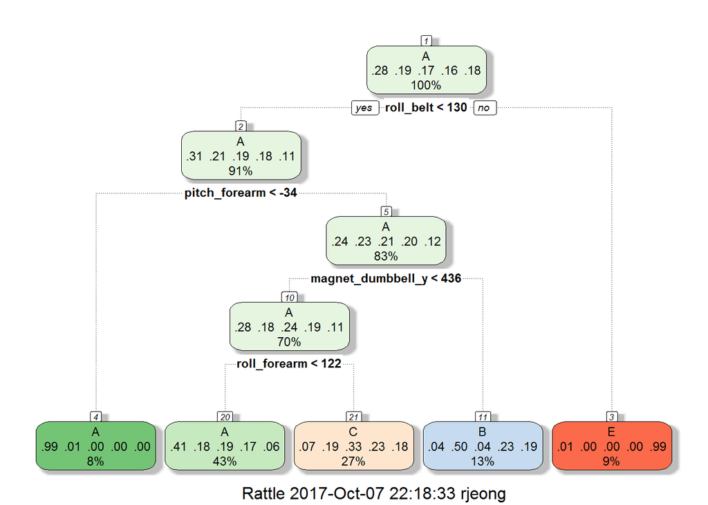

```r
library(rattle)
library(rpart.plot)
fancyRpartPlot(rPartFit1$finalModel)
```

### Random Forest

```r
# Random Forest
rfFit2 <- train(classe ~ ., data = aTrain, method="rf", trControl = trainControl(method="cv", number=5, verboseIter=FALSE), allowParallel=TRUE)
rfFit2
```

```
## Random Forest
##
## 11776 samples
##    52 predictor
##     5 classes: 'A', 'B', 'C', 'D', 'E'
##
## No pre-processing
## Resampling: Cross-Validated (5 fold)
## Summary of sample sizes: 9420, 9421, 9420, 9422, 9421
## Resampling results across tuning parameters:
##
##   mtry  Accuracy   Kappa
##    2    0.9878574  0.9846366
##   27    0.9880265  0.9848538
##   52    0.9797904  0.9744316
##
## Accuracy was used to select the optimal model using  the largest value.
## The final value used for the model was mtry = 27.
```

### RPART Model vs RF Model on Test data set

```r
# rpart
predFit1 <- predict(rPartFit1, newdata=aTest)
cmFit1 <- confusionMatrix(aTest$classe, predFit1)
cmFit1
```

```
## Confusion Matrix and Statistics
##
##           Reference
## Prediction    A    B    C    D    E
##          A 2016   35  176    0    5
##          B  644  520  354    0    0
##          C  638   41  689    0    0
##          D  587  231  468    0    0
##          E  216  203  384    0  639
##
## Overall Statistics
##
##                Accuracy : 0.4925
##                  95% CI : (0.4814, 0.5036)
##     No Information Rate : 0.5227
##     P-Value [Acc > NIR] : 1
##
##                   Kappa : 0.3364
##  Mcnemar's Test P-Value : NA
##
## Statistics by Class:
##
##                      Class: A Class: B Class: C Class: D Class: E
## Sensitivity            0.4916  0.50485  0.33269       NA  0.99224
## Specificity            0.9423  0.85358  0.88242   0.8361  0.88850
## Pos Pred Value         0.9032  0.34256  0.50365       NA  0.44313
## Neg Pred Value         0.6286  0.91941  0.78666       NA  0.99922
## Prevalence             0.5227  0.13128  0.26396   0.0000  0.08208
## Detection Rate         0.2569  0.06628  0.08782   0.0000  0.08144
## Detection Prevalence   0.2845  0.19347  0.17436   0.1639  0.18379
## Balanced Accuracy      0.7170  0.67922  0.60756       NA  0.94037
```

```r
# rf
predFit2 <- predict(rfFit2, newdata=aTest)
cmFit2 <- confusionMatrix(aTest$classe, predFit2)
cmFit2
```

```
## Confusion Matrix and Statistics
##
##           Reference
## Prediction    A    B    C    D    E
##          A 2226    5    1    0    0
##          B    9 1501    8    0    0
##          C    0    7 1356    5    0
##          D    0    0   14 1272    0
##          E    0    5    0    7 1430
##
## Overall Statistics
##
##                Accuracy : 0.9922
##                  95% CI : (0.99, 0.994)
##     No Information Rate : 0.2849
##     P-Value [Acc > NIR] : < 2.2e-16
##
##                   Kappa : 0.9902
##  Mcnemar's Test P-Value : NA
##
## Statistics by Class:
##
##                      Class: A Class: B Class: C Class: D Class: E
## Sensitivity            0.9960   0.9888   0.9833   0.9907   1.0000
## Specificity            0.9989   0.9973   0.9981   0.9979   0.9981
## Pos Pred Value         0.9973   0.9888   0.9912   0.9891   0.9917
## Neg Pred Value         0.9984   0.9973   0.9964   0.9982   1.0000
## Prevalence             0.2849   0.1935   0.1758   0.1637   0.1823
## Detection Rate         0.2837   0.1913   0.1728   0.1621   0.1823
## Detection Prevalence   0.2845   0.1935   0.1744   0.1639   0.1838
## Balanced Accuracy      0.9975   0.9931   0.9907   0.9943   0.9991
```

## Conclusion

We conclude that Random Forest (rf) algorithm produced the most accurate prediction of 98.8% on the training set and producing a 99.22% accuracy on the test set.

## Appendix

### Summary of the 53 variables

```r
summary(nTrain)
```

```
##    roll_belt        pitch_belt          yaw_belt       total_accel_belt
##  Min.   :-28.90   Min.   :-55.8000   Min.   :-180.00   Min.   : 0.00
##  1st Qu.:  1.10   1st Qu.:  1.7600   1st Qu.: -88.30   1st Qu.: 3.00
##  Median :113.00   Median :  5.2800   Median : -13.00   Median :17.00
##  Mean   : 64.41   Mean   :  0.3053   Mean   : -11.21   Mean   :11.31
##  3rd Qu.:123.00   3rd Qu.: 14.9000   3rd Qu.:  12.90   3rd Qu.:18.00
##  Max.   :162.00   Max.   : 60.3000   Max.   : 179.00   Max.   :29.00
##   gyros_belt_x        gyros_belt_y       gyros_belt_z
##  Min.   :-1.040000   Min.   :-0.64000   Min.   :-1.4600
##  1st Qu.:-0.030000   1st Qu.: 0.00000   1st Qu.:-0.2000
##  Median : 0.030000   Median : 0.02000   Median :-0.1000
##  Mean   :-0.005592   Mean   : 0.03959   Mean   :-0.1305
##  3rd Qu.: 0.110000   3rd Qu.: 0.11000   3rd Qu.:-0.0200
##  Max.   : 2.220000   Max.   : 0.64000   Max.   : 1.6200
##   accel_belt_x       accel_belt_y     accel_belt_z     magnet_belt_x
##  Min.   :-120.000   Min.   :-69.00   Min.   :-275.00   Min.   :-52.0
##  1st Qu.: -21.000   1st Qu.:  3.00   1st Qu.:-162.00   1st Qu.:  9.0
##  Median : -15.000   Median : 35.00   Median :-152.00   Median : 35.0
##  Mean   :  -5.595   Mean   : 30.15   Mean   : -72.59   Mean   : 55.6
##  3rd Qu.:  -5.000   3rd Qu.: 61.00   3rd Qu.:  27.00   3rd Qu.: 59.0
##  Max.   :  85.000   Max.   :164.00   Max.   : 105.00   Max.   :485.0
##  magnet_belt_y   magnet_belt_z       roll_arm         pitch_arm
##  Min.   :354.0   Min.   :-623.0   Min.   :-180.00   Min.   :-88.800
##  1st Qu.:581.0   1st Qu.:-375.0   1st Qu.: -31.77   1st Qu.:-25.900
##  Median :601.0   Median :-320.0   Median :   0.00   Median :  0.000
##  Mean   :593.7   Mean   :-345.5   Mean   :  17.83   Mean   : -4.612
##  3rd Qu.:610.0   3rd Qu.:-306.0   3rd Qu.:  77.30   3rd Qu.: 11.200
##  Max.   :673.0   Max.   : 293.0   Max.   : 180.00   Max.   : 88.500
##     yaw_arm          total_accel_arm  gyros_arm_x        gyros_arm_y
##  Min.   :-180.0000   Min.   : 1.00   Min.   :-6.37000   Min.   :-3.4400
##  1st Qu.: -43.1000   1st Qu.:17.00   1st Qu.:-1.33000   1st Qu.:-0.8000
##  Median :   0.0000   Median :27.00   Median : 0.08000   Median :-0.2400
##  Mean   :  -0.6188   Mean   :25.51   Mean   : 0.04277   Mean   :-0.2571
##  3rd Qu.:  45.8750   3rd Qu.:33.00   3rd Qu.: 1.57000   3rd Qu.: 0.1400
##  Max.   : 180.0000   Max.   :66.00   Max.   : 4.87000   Max.   : 2.8400
##   gyros_arm_z       accel_arm_x       accel_arm_y      accel_arm_z
##  Min.   :-2.3300   Min.   :-404.00   Min.   :-318.0   Min.   :-636.00
##  1st Qu.:-0.0700   1st Qu.:-242.00   1st Qu.: -54.0   1st Qu.:-143.00
##  Median : 0.2300   Median : -44.00   Median :  14.0   Median : -47.00
##  Mean   : 0.2695   Mean   : -60.24   Mean   :  32.6   Mean   : -71.25
```

[output cut: 50 more lines]

```
##  Max.   :311.00000   Max.   :231.0000   Max.   : 477.00   Max.   : 923.0
##  accel_forearm_z   magnet_forearm_x  magnet_forearm_y magnet_forearm_z
##  Min.   :-446.00   Min.   :-1280.0   Min.   :-896.0   Min.   :-973.0
##  1st Qu.:-182.00   1st Qu.: -616.0   1st Qu.:   2.0   1st Qu.: 191.0
##  Median : -39.00   Median : -378.0   Median : 591.0   Median : 511.0
##  Mean   : -55.29   Mean   : -312.6   Mean   : 380.1   Mean   : 393.6
##  3rd Qu.:  26.00   3rd Qu.:  -73.0   3rd Qu.: 737.0   3rd Qu.: 653.0
##  Max.   : 291.00   Max.   :  672.0   Max.   :1480.0   Max.   :1090.0
##  classe
##  A:5580
##  B:3797
##  C:3422
##  D:3216
##  E:3607
##
```

##### Tools And Prerequisites For Analysis

###### **RStudio** and **R**, an open source programming language, is used for this analysis. R version 3.3.2 (2016-10-31)

###### Report compiled in `knitr` as a PDF and HTML output.

[^1]: Velloso, E.; Bulling, A.; Gellersen, H.; Ugulino, W.; Fuks, H. [Qualitative Activity Recognition of Weight Lifting Exercises](http://web.archive.org/web/20161224072740/http:/groupware.les.inf.puc-rio.br/work.jsf?p1=11201). Proceedings of 4th International Conference in Cooperation with SIGCHI (Augmented Human ’13) . Stuttgart, Germany: ACM SIGCHI, 2013.